# File-Name: demographics and crime stats_v1

# FINAL GRAPHS for 03/08/17 class:

```r
#stop and frisk events by race:
stops_by_race_graph <- ggplot(stops_by_race2, aes(x = race, y = count, fill = race)) +
  geom_bar(stat = "identity") +
  theme(axis.text.x = element_text(angle = 70, hjust = 1)) +
  ylab("Number of Stop & Frisk Events") +
  xlab("Race") +
  ggtitle("Stop & Frisk Events by Race") +
  geom_text(aes(label = count), vjust = 0, colour = "black") +
  scale_color_brewer(palette = "Greens") +
  theme(axis.line = element_blank(),
        axis.text.y = element_blank(),
        axis.ticks = element_blank(),
        #axis.title.x = element_blank(),
        axis.title.y = element_blank(),
        legend.position = "none",
        panel.background = element_blank(),
        panel.border = element_blank(),
        panel.grid.major = element_blank(),
        panel.grid.minor = element_blank(),
        plot.background = element_blank())

stops_by_race2
```

```
##                                  stops_by_race2
## American Indian / Alaskan Native             76
## Asian / Pacific Islander                   1043
## Black                                     12919
## White                                      2389
## White - Hispanic                           4907
## NA's                                        413
##                                                              race count
## American Indian / Alaskan Native American Indian / Alaskan Native    76
## Asian / Pacific Islander                 Asian / Pacific Islander  1043
## Black                                                       Black 12919
## White                                                       White  2389
## White - Hispanic                                 White - Hispanic  4907
## NA's                                                         NA's   413
```

```r
# new race categories in pop file:
# group pop races as such to match the stop and frisk race categories:
## "tp_One race_American Indian and Alaska Native" - row 31
## "tp_One race_Asian" (row 36) + "tp_One race_Native Hawaiian and Other Pacific Islander" (row 44) = one category
## "tp_One race_Black or African American" row 30
## "tp_One race_White" row 29
## "tp_HISPANIC OR LATINO AND RACE_Not Hispanic or Latino_White alone" (row 67) footnote: (b) Hispanics may be of any race, so also are included in applicable race categories


demographic2 <- data.frame(subset(pop[c(31, 36, 44, 30, 29, 67), 1:2]))

typeof(demographic2$Estimate)
```

```
## [1] "integer"
```

```r
str(demographic2)
```

```
## 'data.frame':    6 obs. of  2 variables:
##  $ Subject : Factor w/ 77 levels "Total housing units",..: 45 50 59 58 65 41
##  $ Estimate: Factor w/ 76 levels "0","1,060,732",..: 63 50 60 41 28 12
```

```r
demographic2$Estimate <- as.numeric(gsub(",", "", as.character(demographic2$Estimate)))
demographic2
```

```
##                                                              Subject
## 31                     tp_One race_American Indian and Alaska Native
## 36                                                 tp_One race_Asian
## 44            tp_One race_Native Hawaiian and Other Pacific Islander
## 30                             tp_One race_Black or African American
## 29                                                 tp_One race_White
## 67 tp_HISPANIC OR LATINO AND RACE_Not Hispanic or Latino_White alone
##    Estimate
## 31     7980
## 36    52457
## 44      666
## 30   475378
## 29   299869
## 67   146928
```

```r
demographic2[ , 1]
```

```
## [1] tp_One race_American Indian and Alaska Native
## [2] tp_One race_Asian
## [3] tp_One race_Native Hawaiian and Other Pacific Islander
## [4] tp_One race_Black or African American
## [5] tp_One race_White
## [6] tp_HISPANIC OR LATINO AND RACE_Not Hispanic or Latino_White alone
## 77 Levels: Total housing units Total population ... tp_Under 5 years
```

```r
demographic2$Subject <- c("American Indian and Alaska Native",
              "Asian",
              "Native Hawaiian and Other Pacific Islander",
              "Black or African American",
              "White",
              "White - Hispanic")

#combine "Asian" and "Native Hawaiian and Other Pacific Islander" to match races in sfd file:
52457 + 666
```

```
## [1] 53123
```

```r
demographic3 <- data.frame(Subject = c("Asian/Native Hawaiian and Other Pacific Islander"),
                           Estimate = 53123)
demographic4 <- demographic2[-c(2:3) , 1:2]
demographic4
```

```
##                              Subject Estimate
## 31 American Indian and Alaska Native     7980
## 30         Black or African American   475378
## 29                             White   299869
## 67                  White - Hispanic   146928
```

```r
demographic4[5, 1:2] <- demographic3
demographic4
```

```
##                              Subject Estimate
## 31 American Indian and Alaska Native     7980
## 30         Black or African American   475378
## 29                             White   299869
## 67                  White - Hispanic   146928
## 1                                  1    53123
```

```r
# demographic4[5, 2] <- demographic3[c("Asian/Native Hawaiian and Other Pacific Islander"), c("53123")]
demographic4[5, 1] <- "Asian/Native Hawaiian and Other Pacific Islander"
demographic4
```

```
##                                             Subject Estimate
## 31                American Indian and Alaska Native     7980
## 30                        Black or African American   475378
## 29                                            White   299869
## 67                                 White - Hispanic   146928
## 1  Asian/Native Hawaiian and Other Pacific Islander    53123
```

```r
population_race_graph <- ggplot(demographic4, aes(x = Subject, y = Estimate, fill = Subject)) +
  geom_bar(stat = "identity") +
  theme(axis.text.x = element_text(angle = 70, hjust = 1)) +
  xlab("Race") +
  ylab("Population Estimate") +
  ggtitle("2015 Bronx Population by Race") +
  geom_text(aes(label = Estimate), vjust = 0.05, colour = "black") +
  scale_color_brewer(palette = "Greens") +
  theme(axis.line = element_blank(),
        axis.text.y = element_blank(),
        axis.ticks = element_blank(),
        #axis.title.x = element_blank(),
        axis.title.y = element_blank(),
        legend.position = "none",
        panel.background = element_blank(),
        panel.border = element_blank(),
        panel.grid.major = element_blank(),
        panel.grid.minor = element_blank(),
        plot.background = element_blank())

#percentage comparison stop and frisk events / pop race cat:
stops_by_race2
```

```
##                                  stops_by_race2
## American Indian / Alaskan Native             76
## Asian / Pacific Islander                   1043
## Black                                     12919
## White                                      2389
## White - Hispanic                           4907
## NA's                                        413
##                                                              race count
## American Indian / Alaskan Native American Indian / Alaskan Native    76
## Asian / Pacific Islander                 Asian / Pacific Islander  1043
## Black                                                       Black 12919
## White                                                       White  2389
## White - Hispanic                                 White - Hispanic  4907
## NA's                                                         NA's   413
```

```r
demographic4
```

```
##                                             Subject Estimate
## 31                American Indian and Alaska Native     7980
## 30                        Black or African American   475378
## 29                                            White   299869
## 67                                 White - Hispanic   146928
## 1  Asian/Native Hawaiian and Other Pacific Islander    53123
```

```r
AIAN <- round(((76 / 7980) * 100), digits = 2) # "American Indian / Alaskan Native"
API <- round(((1043 /   53123) * 100), digits = 2) # "Asian / Pacific Islander"
BLK <- round(((12919    / 475378) * 100), digits = 2) # "Black"
WHT <- round(((2389 / 299869) * 100), digits = 2) # "White"
WH <- round(((4907 / 146928) * 100), digits = 2) # "White - Hispanic"

#MAKE THIS INTO A MATRIX AND WRITE UP A QUICK SUMMARY FOR WEDNESDAY
comparison <- matrix(c("Race", "% of each race who were stopped and frisked",
         "American Indian / Alaskan Native", AIAN,
         "Asian / Pacific Islander", API,
         "Black", BLK,
         "White", WHT,
         "White - Hispanic", WH),
       nrow = ,
       ncol = 2,
       byrow = TRUE)

comparison2 <- as.data.frame(comparison)

comparison2
```

```
##                                 V1
## 1                             Race
## 2 American Indian / Alaskan Native
## 3         Asian / Pacific Islander
## 4                            Black
## 5                            White
## 6                 White - Hispanic
##                                            V2
## 1 % of each race who were stopped and frisked
## 2                                        0.95
## 3                                        1.96
## 4                                        2.72
## 5                                         0.8
## 6                                        3.34
```

```r
comparison2 <- comparison2[-1, 1:2]

comparison2
```

```
##                                 V1   V2
## 2 American Indian / Alaskan Native 0.95
## 3         Asian / Pacific Islander 1.96
## 4                            Black 2.72
## 5                            White  0.8
## 6                 White - Hispanic 3.34
```

```r
comparison_graph <- ggplot(comparison2, aes(x = V1, y = V2, fill = V1)) +
  geom_bar(stat = "identity") +
  theme(axis.text.x = element_text(angle = 70, hjust = 1)) +
  xlab("Race") +
  ylab("Percentage") +
  ggtitle("Percentage of Each Race of the Bronx Population Being Stopped & Frisked") +
  geom_text(aes(label = V2), vjust = 0, colour = "black") +
  theme(axis.line = element_blank(),
        axis.text.y = element_blank(),
        axis.ticks = element_blank(),
        #axis.title.x = element_blank(),
        axis.title.y = element_blank(),
        legend.position = "none",
        panel.background = element_blank(),
        panel.border = element_blank(),
        panel.grid.major = element_blank(),
        panel.grid.minor = element_blank(),
        plot.background = element_blank())
```

**03/08/17 Class Update for Team 3:**

1. Gathered demographic data for the Bronx and compared it to stop and frisk events by race. NYPD crime data were also gathered and will be cleaned within the coming weeks to understand the relationship between the reasons police officers  
   stop and frisk versus population crimes in the Bronx by precinct (to pinpoint location). Next, we will start to build our forecasting models for probability of being stopped and frisked in the Bronx by race, use of force, gender, and other potential variables.
2. The output (graphs) for the week show the breakdown of 5 races by population in the Bronx, stop and frisk events by race, and stop and frisk events by race as a percentage of each race within the Bronx population, respectively. All data are for the Bronx in 2015.

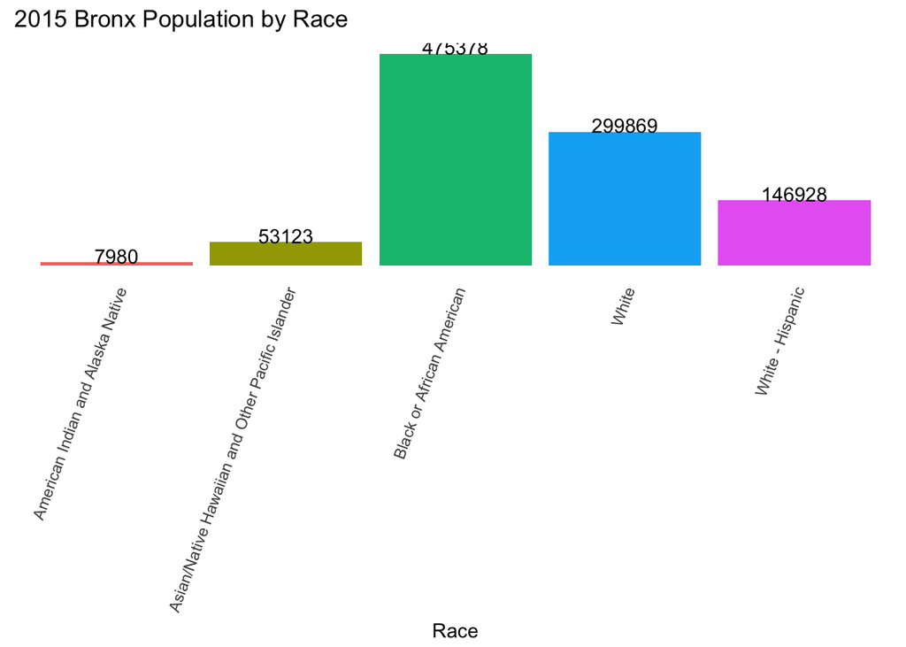

```r
population_race_graph
```

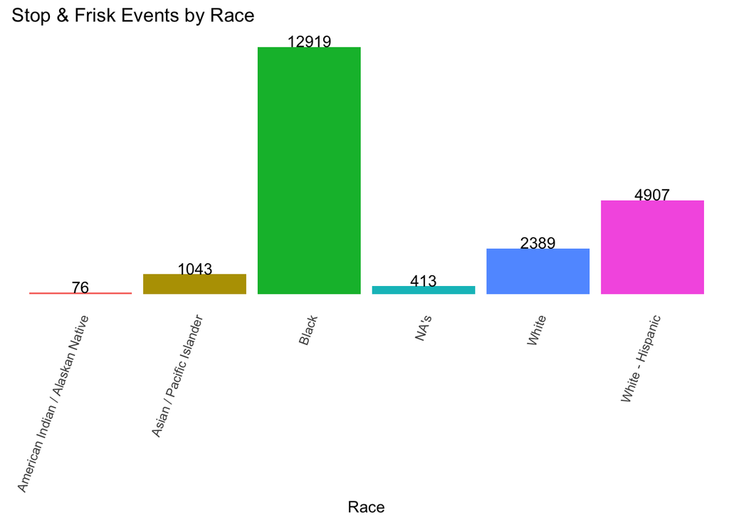

```r
stops_by_race_graph
```

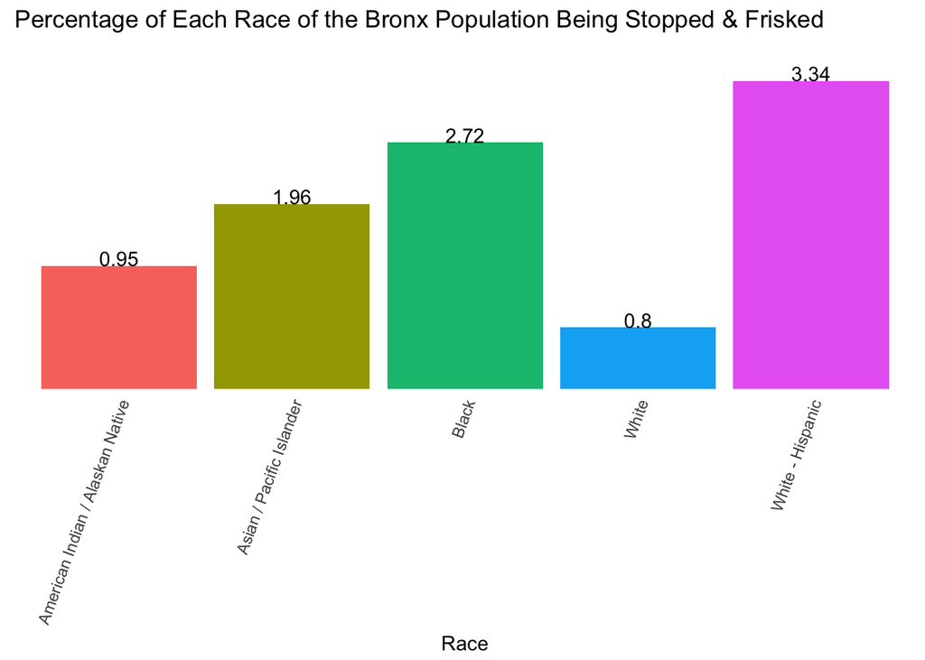

```r
comparison_graph
```

# Crime Stats for the Bronx: general:

# Clean the data:

https://stackoverflow.com/questions/37509886/how-to-read-merged-excel-cells-with-r

```r
rm(list = ls(all = TRUE))   # cleans everything in the workspace

path <- "/Users/StephanieLangeland/Desktop/Columbia/Applied Data Science/Git/QMSS_G5069_Applied_D_S/Data+Code Book/Raw:Outdated/crime data_combined_raw2.csv"

raw_crime <- read.csv(path)
raw_crime1 <- raw_crime ## create raw_crime1 to alter the data so that raw_crime stays in its original form

raw_crime1 <- raw_crime1[!grepl("TOTAL", raw_crime1$CRIME),] ## remove the rows with totals

raw_crime_2015 <- raw_crime1 ## create a dataset to store only 2015 data

raw_crime_2015 <- raw_crime_2015[ , -c(4:18)] ## remove all years that are not 2015

colnames(raw_crime_2015)[4] <- "crimes_count" ## since all data are form 2015, rename raw_crime_2015$X2015

colnames(raw_crime_2015)[3] <- "crime" ## rename raw_crime_2015$CRIME with lowercase column heading for consistency

colnames(raw_crime_2015)[2] <- "pct" ## rename raw_crime_2015$PCT with lowercase column heading for consistency

cleaned_2015_crime_data <- write.csv(raw_crime_2015, file = "cleaned_2015_crime_data.csv")
```